# Newsletter Design and Reservation Growth

Proposal Presentation: The Restaurant at Kellogg Ranch

Leeann Lewis-Waddell

IBM 6500, Cal Poly Pomona

November 15, 2026

# Introduction

The Collins Concierge is a channel RKR already owns. This project asks how to make its RKR section work harder.

## Problem Statement

- RKR is moving from an instructional restaurant to a **dual model** that adds stand-alone service days (Kwok 2026).
- Stand-alone days cannot rely on state funding, so they need **steady reservations** to stay viable (Kwok 2026).
- The Collins Concierge already reaches faculty and staff, the segment that best fits RKR’s weekday lunch hours (The Restaurant at Kellogg Ranch n.d.).

**The gap**

The RKR section is mostly text, and the “Reserve a Table” button sits at the bottom, below the hours.<sup>1</sup> Readers who skim can scroll past it.

[^1]: Based on the team’s review of current Concierge issues, Fall 2026.

## Analytics Objective

**PO1:** Strengthen the visual design of RKR’s section of The Collins Concierge to drive reservation growth.

**AO1:** Compare RKR click rates and attributed OpenTable reservations across RKR newsletter section designs, testing button placement in Fall 2026 and image versus video in Spring 2027.

Fall 2026 Move “Reserve a Table” to the upper left, compared with past issues

Spring 2027 A/B test image vs. video, with the button fixed in the upper left

## Importance

### Reaches the primary segment

Faculty and staff rated highest in the team’s segment analysis, and the Concierge reaches them directly.

### Low cost, already owned

No ad spend. The section runs every week, so each issue is a chance to test.

### Measurable end to end

Canva tracks views and clicks; version-specific links can tie clicks to OpenTable bookings.

One change  
at a time.

Clicks show interest, not bookings. Reservations remain the secondary, validating measure (Kumar 2021).

# Literature Review

Three frameworks shape how the test is built: the email response process, visual attention, and cognitive load.

## Well-established Models

| Framework | Key finding | What it means for AO1 |
| --- | --- | --- |
| **Email response process** | Newsletter response moves from seeing, to engaging, to acting; format tests against a control work well (Hartemo, Suomi, and Hakala 2016) | Use past issues as the control baseline |
| **Relational vs. transactional metrics** | Across 811 newsletters, clicks had the strongest link to eventual purchase (Kumar 2021) | Click-through rate is the primary metric |
| **Visual heuristics** | Readers scan newsletters in a U-shape; upper-left links earn higher CTR (Kumar and Salo 2018) | Fall moves the button to the upper left |
| **Visual attention** | Large images drew more attention than prices or codes, and attention mapped to purchase (Skourou and Spiliotopoulos 2024) | Spring tests image vs. video |
| **Cognitive load** | GIFs and emojis together raised unsubscribes, though neither hurt CTR alone (Bashirzadeh, Mai, and Faure 2022) | Add only one visual element at a time |

## Challenges in the Literature

**Inbox overload**

University recipients reported about 30 bulk emails a week and trashed 22% of newsletters (Kong, Zhu, and Konstan 2021). Academics at one business school received 324 organizational bulk emails in a year (Bicudo De Castro 2025).

**Email needs a clear role**

Readers resisted email that did not fit their customer journey (Zunac, Miletic, and Kozina 2022).

**Implication:** A redesign may not move CTR if readers never reach the RKR section. AO1 tracks **views alongside clicks** to separate a design problem from a readership problem.

## Adequacy of the Information

### Strengths

- Covers attention, button placement, media, and fatigue
- Findings line up with industry guidance (Go 2024; Jones 2023)
- Directly actionable for a newsletter section

### Limitations

- Industry guides come from companies selling services
- The eye-tracking study had a small sample (Skourou and Spiliotopoulos 2024)
- The email-role study was mostly female participants (Zunac, Miletic, and Kozina 2022)

**The gap:** No reviewed study looks at a **restaurant section inside a university newsletter**. Primary data from the Concierge fills it.

## Need for Additional Analysis

1. **Build a baseline** of RKR click rates from past Concierge issues in Canva.
2. **Fall 2026:** measure the effect of moving the button to the upper left.
3. **Spring 2027:** alternate image and video issues weekly, button fixed.
4. **Tag links by version** so OpenTable bookings trace back to the design.
5. **Flag unusual weeks** such as holidays, finals, and campus events.

# Methods

Secondary data from Canva website insights, analyzed issue by issue.

## Data and Sampling

- **Source:** Canva website insights for The Collins Concierge, exported as one CSV per issue
- **Window:** the last 12 weeks of issues
- **Sampling:** all available issues in the window (non-probability, convenience)
- **Cleaning:** 14 exports received; 1 byte-identical duplicate removed, leaving **13 issues**

2,681

total page views across 13 issues

The “Reserve a Table” button links to the RKR website rather than straight to OpenTable, so clicks to cpp.edu/rkr pages are the measurable step before a booking.

## Data Wrangling

Each export stacks four dimensions (country, device, source, link) in long format. The code below collapses them to one row per issue.

```r
issue_summary <- issues |>
  group_by(issue) |>
  summarise(
    views       = sum(Count[Dimension == "country"]),
    mobile      = sum(Count[Dimension == "device" & Name == "Mobile"]),
    link_clicks = sum(Count[Dimension == "link"]),
    rkr_clicks  = sum(Count[Dimension == "link" &
                            str_detect(Name, "cpp\\.edu/rkr")]),
    .groups = "drop") |>
  mutate(ctr = rkr_clicks / views)
```

## Sample Characteristics

- Average views per issue: **206**
- Mobile share of views: **41%**
- Total RKR clicks: **50**
- Issues with zero RKR clicks: **2**

| Issue | Views | Mobile % | All link clicks | RKR clicks | RKR CTR |
| --- | --- | --- | --- | --- | --- |
| 1 | 98 | 41% | 38 | 0 | 0.0% |
| 2 | 85 | 45% | 25 | 0 | 0.0% |
| 3 | 428 | 40% | 145 | 1 | 0.2% |
| 4 | 238 | 37% | 133 | 1 | 0.4% |
| 5 | 204 | 37% | 127 | 12 | 5.9% |
| 6 | 228 | 37% | 116 | 4 | 1.8% |
| 7 | 190 | 39% | 99 | 4 | 2.1% |
| 8 | 180 | 38% | 74 | 6 | 3.3% |
| 9 | 221 | 48% | 72 | 2 | 0.9% |
| 10 | 131 | 37% | 26 | 2 | 1.5% |
| 11 | 280 | 45% | 91 | 10 | 3.6% |
| 12 | 230 | 35% | 87 | 6 | 2.6% |
| 13 | 168 | 56% | 41 | 2 | 1.2% |

## Measures

| Variable | Measurement or coding | Role in AO1 |
| --- | --- | --- |
| Design condition | Past issues vs. upper-left button (Fall); photo vs. video (Spring) | Independent variable |
| Issue date | Publication date of each weekly issue | Links clicks and bookings to the right condition |
| Page views | Views reported by Canva for each issue | Denominator for click rate |
| RKR clicks | Clicks to cpp.edu/rkr pages from the RKR section | Numerator for click rate |
| Click-through rate | RKR clicks ÷ page views | Primary outcome |
| Attributed reservations | Weekly OpenTable bookings through version-specific links | Secondary outcome |
| Unusual weeks | Holidays, breaks, campus events, RKR promotions | Context flag |

## Baseline: RKR Click Rate by Issue

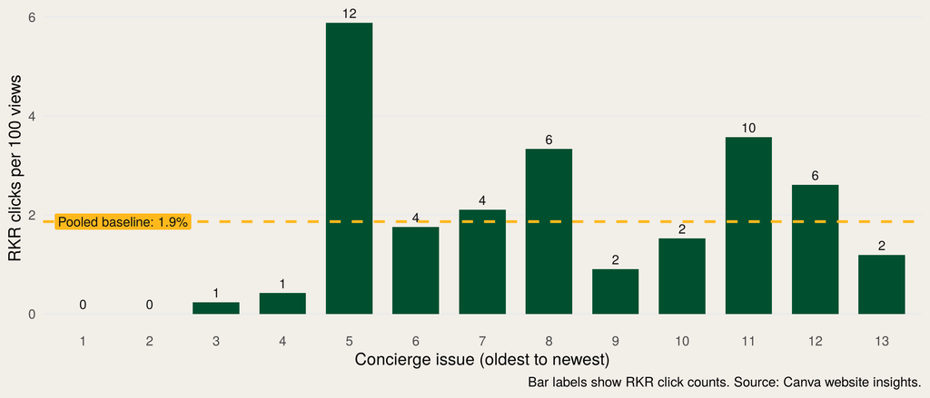

## Analytics Methods

### A/B testing in two phases

Only one element changes per phase, so any difference in clicks can be traced to that change.

### Two-proportion z-test

Compares click rates between conditions at α = 0.05:

$$z = \frac{\hat{p}_1 - \hat{p}_2}{\sqrt{\hat{p}(1-\hat{p})\left(\frac{1}{n_1} + \frac{1}{n_2}\right)}}$$

### Independent-samples t-test

Compares the average weekly OpenTable reservations attributed to each design.

### Why these methods

- The z-test is the standard way to compare two rates
- The t-test fits weekly reservation counts across two groups
- Together they follow the reader’s path from **view → click → booking** (Hartemo, Suomi, and Hakala 2016)

# References

Bashirzadeh, Yashar, Robert Mai, and Corinne Faure (2022), “[How rich is too rich? Visual design elements in digital marketing communications](https://doi.org/10.1016/j.ijresmar.2021.06.008),” *International Journal of Research in Marketing*, 39 (1), 58–76.

Bicudo De Castro, Vicente (2025), “[Quantifying the burden of organisational bulk emails in a business school](https://doi.org/10.1080/07294360.2025.2510662),” *Higher Education Research & Development*, 44 (8), 1934–48.

Go, Sydney (2024), “[What is email marketing? The definitive guide for beginners](https://www.semrush.com/blog/email-marketing).”

Hartemo, Mari, Reima Suomi, and Ulla Hakala (2016), “[Towards improved performance: A model for testing email newsletter design](https://doi.org/10.4018/JECO.2016070101),” *Journal of Electronic Commerce in Organizations*, 14 (3), 1–16.

Jones, Alexandra (2023), “[The complete restaurant email marketing guide](https://www.opentable.com/restaurant-solutions/resources/email-marketing-restaurants/).”

Kong, Ruoyan, Haiyi Zhu, and Joseph A. Konstan (2021), “[Learning to ignore: A case study of organization-wide bulk email effectiveness](https://doi.org/10.1145/3449154),” *Proceedings of the ACM on Human-Computer Interaction*, 5 (CSCW1), 1–23.

Kumar, Ashish (2021), “[An empirical examination of the effects of design elements of email newsletters on consumers’ email responses and their purchase](https://doi.org/10.1016/j.jretconser.2020.102349),” *Journal of Retailing and Consumer Services*, 58, 102349.

Kumar, Ashish and Jari Salo (2018), “[Effects of link placements in email newsletters on their click-through rate.](https://doi.org/10.1080/13527266.2016.1147485)” *Journal of Marketing Communications*, 24 (5), 535–48.

Kwok, Linchi (2026), “Building sustainable demand for the restaurant at kellogg ranch: A data-driven brand, content, and digital marketing initiative.”

Skourou, Evangelia and Dimitris Spiliotopoulos (2024), “[Assessment of purchasing influence of email campaigns using eye tracking](https://doi.org/10.3390/mti8100087),” *Multimodal Technologies and Interaction*, 8 (10), 87.

The Restaurant at Kellogg Ranch (n.d.), “Contact us,” California State Polytechnic University, Pomona, (accessed October 11, 2026), [available at https://www.cpp.edu/rkr/contact-us.shtml].

Zunac, Ana Globocnik, Lana Miletic, and Goran Kozina (2022), “[Self-sufficiency of e-mail as a marketing tool](https://www.proquest.com/docview/2735560511/abstract/A22D6AB6B6984192PQ/10),” Varazdin, Croatia: Varazdin Development; Entrepreneurship Agency (VADEA), 147–53.

# Appendix

Links, data notes, and source files.

## Clickable Links

[Group 9 CEP Report (GitHub Pages)](https://lewiswaddell.github.io/GP9CEP-RKR.Kwok/)

[Group 9 GitHub Repository](https://github.com/lewiswaddell/GP9CEP-RKR.Kwok)

[The Restaurant at Kellogg Ranch](https://www.cpp.edu/rkr/)

[RKR Menu Page](https://www.cpp.edu/rkr/menu.shtml)

[RKR on Instagram](https://www.instagram.com/rkr_cpp/)

[CPP Design Toolkit](https://www.cpp.edu/brand/toolkits/design.shtml)

[Quarto Reveal.js Documentation](https://quarto.org/docs/presentations/revealjs/)

[Quarto Pub](https://quartopub.com/)

## Data Notes

- **Files:** 14 Canva CSV exports in `data/concierge-canva/`, one per issue
- **Duplicates:** 1 export was byte-identical to another and was removed with an MD5 check
- **Issue order:** files are sorted by their export timestamp, which follows publication order
- **RKR clicks:** any link containing `cpp.edu/rkr`; no direct OpenTable links appear in the exports
- **Views:** sum of country rows, which matches total page views reported by Canva
- **Not yet available:** issue dates, the first issue with the upper-left button, and OpenTable reservations by link